# MACHINE LEARNING ASSIGNMENT-3

> 3. Split the data into a training set and a test set.

```r
set.seed(1)
train_mpg <- sample(seq_len(nrow(x)), nrow(x) / 2)
training_data_mpg <- x[train_mpg,]
testing_data_mpg <- x[-train_mpg,]
testing_mpg01 <- x[-train_mpg,]$mpg01
```

> 4. Perform LDA on the training data in order to predict `mpg01` using the variables that seemed most associated with `mpg01` in (b). What is the test error of the model obtained?

```r
q6_dfit <- lda(mpg01 ~ cylinders + weight + displacement, data = training_data_mpg)
pred <- predict(q6_dfit, testing_data_mpg, type = "response")$class
(t <- table(pred,testing_mpg01))
```

```
##     testing_mpg01
## pred  0  1
##    0 86  7
##    1 16 87
```

```r
sum(diag(t)) / sum(t)
```

```
## [1] 0.8826531
```

```r
mean(pred != testing_mpg01)
```

```
## [1] 0.1173469
```

> 5. Perform QDA on the training data in order to predict `mpg01` using the variables that seemed most associated with `mpg01` in (b). What is the test error of the model obtained?

```r
q6_efit <- qda(mpg01 ~ cylinders + weight + displacement, data = training_data_mpg)
pred <- predict(q6_efit, testing_data_mpg, type = "response")$class
(t <- table(pred,testing_mpg01))
```

```
##     testing_mpg01
## pred  0  1
##    0 89  9
##    1 13 85
```

```r
sum(diag(t)) / sum(t)
```

```
## [1] 0.8877551
```

```r
mean(pred != testing_mpg01)
```

```
## [1] 0.1122449
```

The overall fraction of error in predictions is 0.1122449. The error rate is 0.1122449 The model mainly predicts “1” instances well but misclassifies some “0” instances as “1”

> 6. Perform logistic regression on the training data in order to predict `mpg01` using the variables that seemed most associated with `mpg01` in (b). What is the test error of the model obtained?

```r
fit <- glm(mpg01 ~ cylinders + weight + displacement, data = training_data_mpg, family = binomial)
pred <- predict(fit, testing_data_mpg, type = "response") > 0.5
(t <- table(pred,testing_mpg01))
```

```
##        testing_mpg01
## pred     0  1
##   FALSE 85  7
##   TRUE  17 87
```

```r
sum(diag(t)) / sum(t)
```

```
## [1] 0.877551
```

```r
mean(pred != testing_mpg01)
```

```
## [1] 0.122449
```

The overall fraction of correct predictions is 0.877551. The error rate is 0.122449. The model identifies most “1” instances well but misclassifies some “0” instances as “1”

> 7. Perform KNN on the training data, with several values of $K$, in order to predict `mpg01`. Use only the variables that seemed most associated with `mpg01` in (b). What test errors do you obtain? Which value of $K$ seems to perform the best on this data set?

```r
res <- sapply(1:50, function(k) {
  fit <- knn(training_data_mpg[ c(2,5,3)], testing_data_mpg[ c(2,5,3)], testing_mpg01, k = k)
  mean(fit != testing_mpg01)
})
names(res) <- 1:50
res[which.min(res)]
```

```
##       34
## 0.377551
```

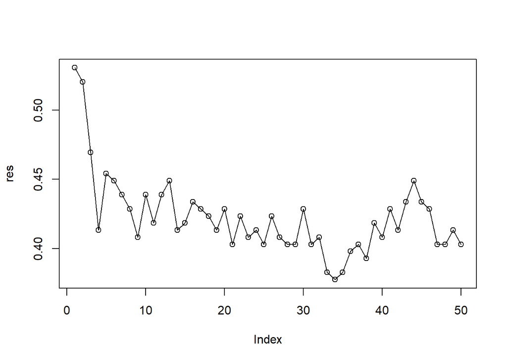

```r
plot(res, type = "o")
```

For the models tested here, $k = 34$ appears to perform best. QDA has a lower error rate overall, performing slightly better than LDA.